```python
import IPython.core.display as di
di.display_html('<script>jQuery(function() {if (jQuery("body.notebook_app").length == 0) { jQuery(".input_area").toggle(); jQuery(".prompt").toggle();}});</script>', raw=True)
```

# Analysis

After doing the data wrangling, we needed to get some insights about data.

**First**, We needed to find correlation between rating, favorites and retweets.

```
Text(0,0.5,'Count')
```

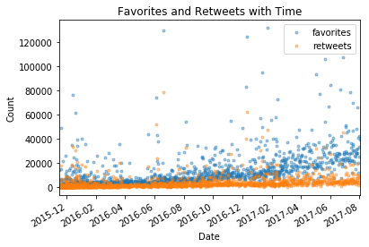

```python
import pandas as pd
import matplotlib.pyplot as plt

df = pd.read_csv('twitter_archive_master.csv')
df['timestamp'] = pd.to_datetime(df['timestamp'])
df.set_index('timestamp', inplace=True)

df[['favorites', 'retweets']].plot(style = '.', alpha = 0.4)
plt.title('Favorites and Retweets with Time')
plt.xlabel('Date')
plt.ylabel('Count')
```

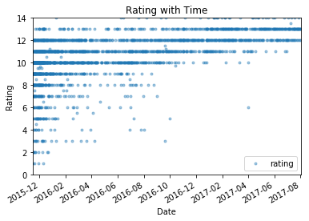

```python
df.plot(y ='rating', ylim=[0,14], style = '.', alpha = 0.4)
plt.title('Rating with Time')
plt.xlabel('Date')
plt.ylabel('Rating');
```

```python
df[['favorites', 'rating', 'retweets']].corr(method='pearson')
```

|  | favorites | rating | retweets |
| --- | --- | --- | --- |
| favorites | 1.000000 | 0.023010 | 0.916447 |
| rating | 0.023010 | 1.000000 | 0.023557 |
| retweets | 0.916447 | 0.023557 | 1.000000 |

All the three quantities have increased with time.

Favorites and retweets had a strong positive correlation. This means that if a tweet is good in general then it will get more retweets and favorites.

Yet there is no correlation between rating and retweets or rating and favorites. It can be because the dogs are not actually getting better. It can be that 'lower quality' dogs are given funnier captions. In this case, it is the caption that is getting more retweets and favorites, rather than the dog itself.

**Next** is the ratings based on dog type.

```python
df.groupby('dog_type')['rating'].describe()
```

| dog_type | count | mean | std | min | 25% | 50% | 75% | max |
| --- | --- | --- | --- | --- | --- | --- | --- | --- |
| doggo | 69.0 | 11.797101 | 1.510548 | 8.0 | 11.0 | 12.0 | 13.0 | 14.0 |
| floof | 34.0 | 11.705882 | 0.759961 | 10.0 | 11.0 | 12.0 | 12.0 | 13.0 |
| pupper | 237.0 | 10.616160 | 1.833623 | 3.0 | 10.0 | 11.0 | 12.0 | 14.0 |
| puppo | 29.0 | 12.172414 | 1.197288 | 9.0 | 12.0 | 13.0 | 13.0 | 14.0 |

```python
df.reset_index(inplace=True)
df.groupby('dog_type')['timestamp'].describe()
```

| dog_type | count | unique | top | freq | first | last |
| --- | --- | --- | --- | --- | --- | --- |
| doggo | 69 | 69 | 2016-11-18 23:35:32 | 1 | 2016-04-02 01:52:38 | 2017-07-26 15:59:51 |
| floof | 34 | 34 | 2016-07-05 20:41:01 | 1 | 2016-01-08 03:50:03 | 2017-07-18 00:07:08 |
| pupper | 237 | 237 | 2016-01-30 02:41:58 | 1 | 2015-11-26 21:36:12 | 2017-07-15 23:25:31 |
| puppo | 29 | 29 | 2017-01-29 02:44:34 | 1 | 2016-06-03 01:07:16 | 2017-07-25 01:55:32 |

Using statistical summary of timestamp column based on dog type showed that 'floof' was not a new term, first seen on January 2016.

So we came to a conclusion that floofer are consistently good dogs.